# Duplication and Polyploidy: Revisited

Macroevolution · PB 495/595 Plant Evolutionary Biology

George P. Tiley

19 November 2026

## Rapid restructuring of genomes

- Whole-genome duplications (WGD) lead to gene family expansions as well as large-scale architectural changes.
- These changes can sometimes lead to new traits or big changes to existing ones.
- We covered examples but need to expand on why we are confident in some conclusions.

## Learning objectives

By the end you should be able to:

- Reconcile gene trees with a species tree to count duplications and losses.
- Understand common approaches to finding synteny between genomes.
- Combine gene trees and synteny to estimate the age of duplication events.
- Explain why the angiosperm-wide duplication $\epsilon$ is disputed.
- Describe fractionation, subgenome dominance and reciprocal gene loss.

# Gene families

## Genes evolve under a birth-death process too

- A **gene family** is every gene descended from one ancestral gene. Families grow by duplication and shrink by loss. These rates are not very far off from the substitution rate per site (Demuth and Hahn 2009), even when accounting for WGD (Tiley, Ané, and Burleigh 2016).
- Duplicates arrive different ways: small-scale duplications, aneuploidies, and WGDs. *Can we tell these cases apart?*

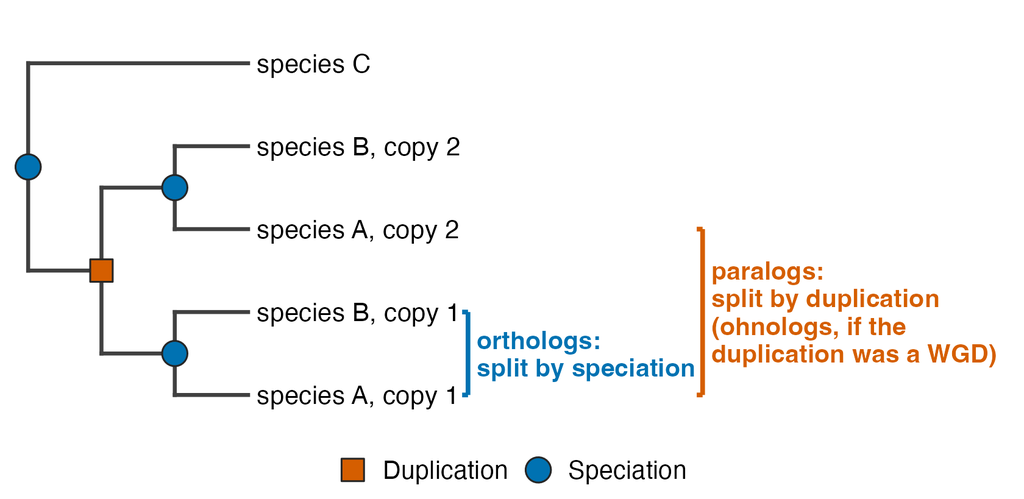

## A gene tree inside a species tree

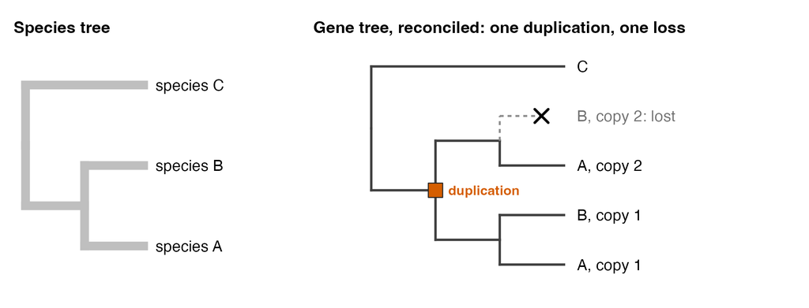

- **Reconciliation** maps each node of the gene tree to the species tree to label duplication and speciation nodes (Goodman et al. 1979)
- The most parsimonious reconciliation can minimize duplications or losses needed to explain the gene tree given the species tree (Page 1994)
- Extensions to co-evolution: map a parasite tree onto a host tree.

## Gene tree reconciliation

A challenge in plant genome evolution:

**Hidden paralogy** - genes may look single-copy, but were duplicated followed by differential loss.

What is a piece of information that might help you differentiate hidden paralogs from orthologs? (hint: think about gene trees)

# Detecting an ancient WGD

## Synteny

- After a WGD every duplicated chromoseome is mostly the same. Fractionation will remove most but the remaining will retain the original gene order if not broken by rearrangements.
- Those runs are **collinear blocks**, and the these regions are called **syntenic** (Tang et al. 2008).
- A *dot plot* is a common way to visualize synteny within a genome or between two genomes.

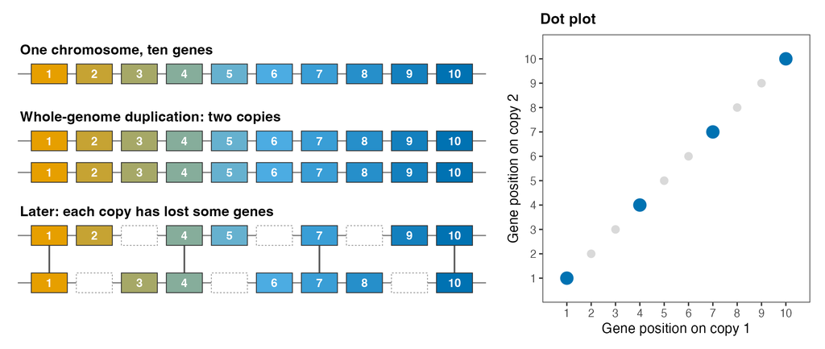

Schematic of collinearity between duplicated chromosomes

## Synteny

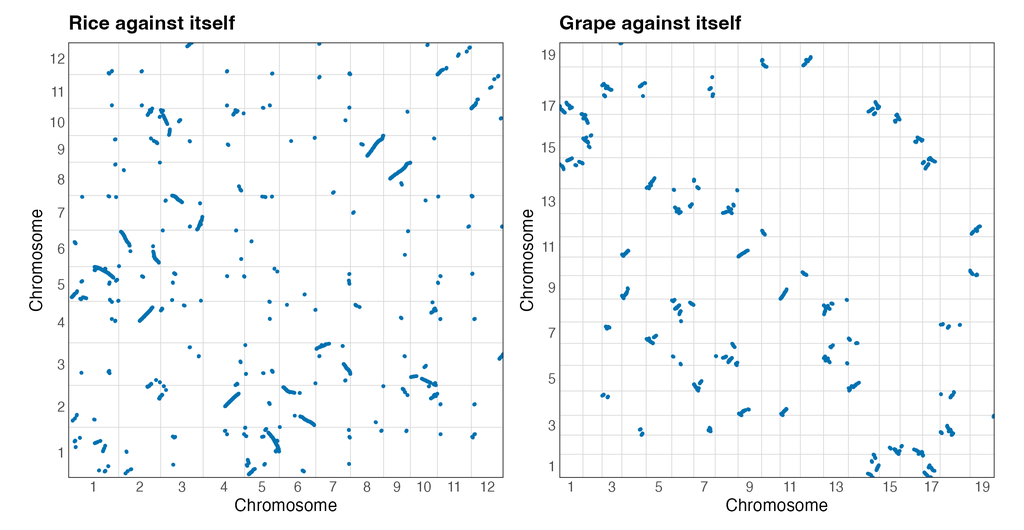

Self-synteny in rice and grape based on collinear pairs from PLAZA 5.0 (Van Bel et al. 2022)

- Rice - long diagonal chains from from $\rho$ (Paterson, Bowers, and Chapman 2004).
- Grape - evidence of the $\gamma$ triplication before the diversification of Eudicots (Jaillon et al. 2007).

## Paralog divergence distributions

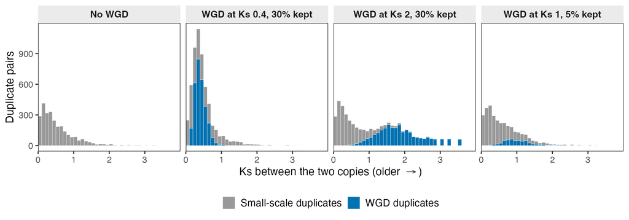

Expected divergence distributions under different retention and age scenarios

- **Ks** is the number of synonymous substitutions per synonymous site. It is a reliable estimate of the neutral evolutionary divergence between duplications (Lynch and Conery 2000).
- Most small-scale duplicates are short-lived and their distribution is a bit exponential looking.
- Possible without high-quality genomes, but most effective when paired with synteny.

## Paralog divergence distributions

Thought experiment: what would the Ks distribution look like if using syntenic duplicates only?

## Bursts of duplications

- Reconciled gene tree should pile up duplications on a WGD branch (Jiao et al. 2011; Li et al. 2015).
- Probabilistic models of gene gain and loss are possible too (Rabier, Ta, and Ané 2014; Tiley, Ané, and Burleigh 2016).
- A simulation of 3,000 gene families. Duplications happen at 0.002 per family per million years, losses at 0.003. At the WGD, each copy is doubled and kept with some probability.

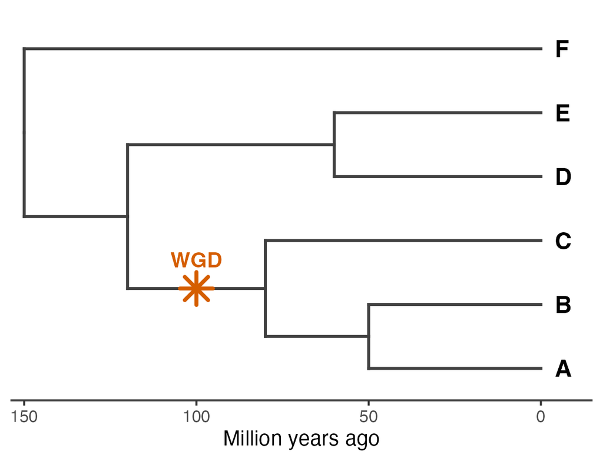

## Bursts of duplications

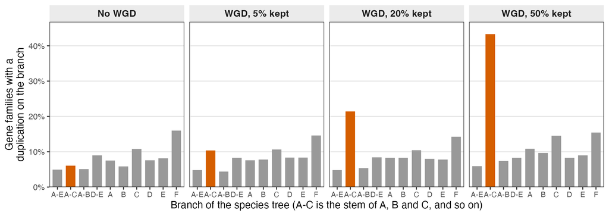

- Half the copies kept: 43% of families show a duplication on the WGD branch. Obvious.
- 5% kept: 10% of families on the stem. The long branch to F has 15% from ordinary duplication alone. Difficult to differentiate from background duplications without synteny.

## The debate over the angiosperm WGD

| Tool | evidence | caveat |
| --- | --- | --- |
| Synteny | an ancient duplication in the *Amborella* genome (Amborella Genome Project 2013) | blocks this old are short and few |
| Ks plots | nothing | too old |
| Gene trees | two bursts of duplication, ζ and ε (Jiao et al. 2011) | dosage-sensitive families show only $\zeta$ (Shi and Van de Peer 2026) |
| Gene counts | nothing and it should be possible (Tiley, Ané, and Burleigh 2016) | low statistical power to differentiate $\zeta$ and $\epsilon$ |

## The debate over the angiosperm WGD

Thought experiment: There is a lot of uncertainty investigating ancient WGDs and their consequences for plant evolution. What would you expect if we used dosage-sensitive gene families only?

## The debate over the angiosperm WGD

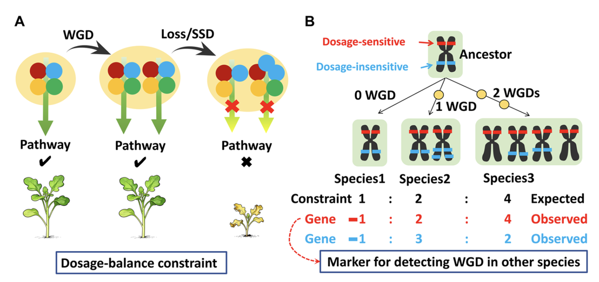

Expectations of dosage-sensitive gene families. Fig. 1 of Shi and Van de Peer (2026)

## The debate over the angiosperm WGD

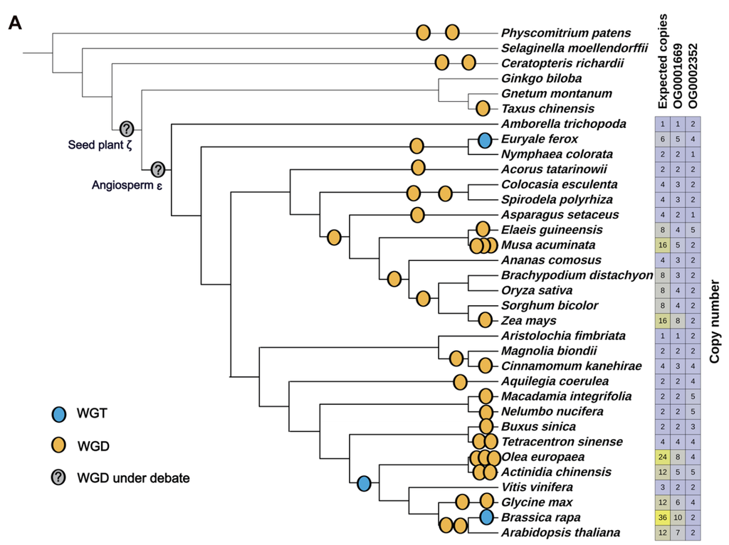

Summary of WGDs across plants. Fig. 2 of Shi and Van de Peer (2026)

## The debate over the angiosperm WGD

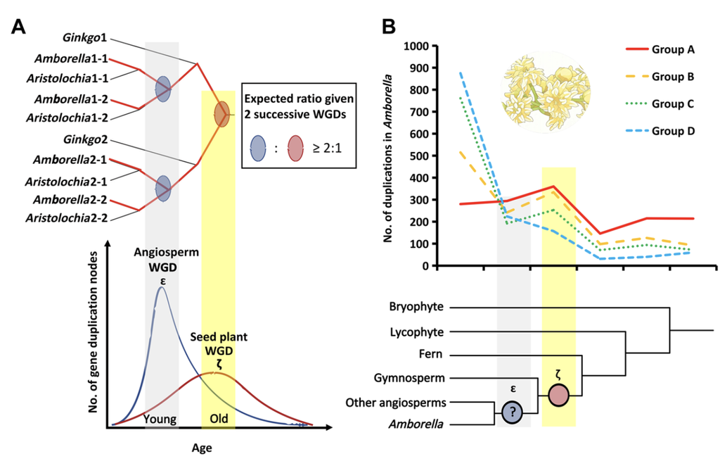

Duplicates pile up around seed plants from dosage-sensitive gene families. Fig. 5 of Shi and Van de Peer (2026)

# After the duplication

## Biased gene loss

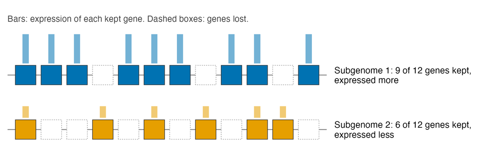

## Genome size: selection against large genomes?

Data from the Plant DNA C-values database (Pellicer et al. 2018).

[output not shown]

## Genome size: selection against large genomes?

Increased extinction risk is associated with larger genome sizes in herbaceous angiosperms (Soto Gomez et al. 2024).

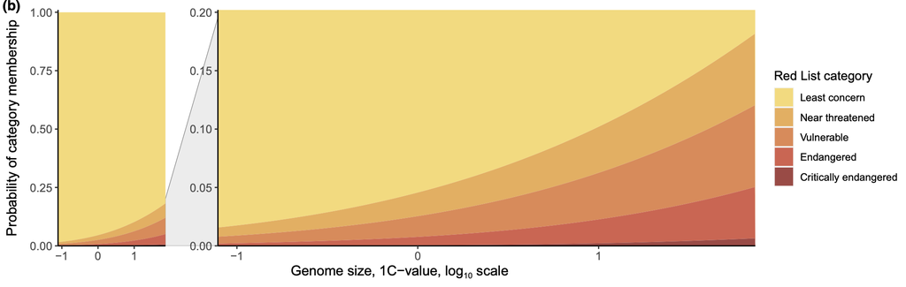

Increased extinction risk implies some fitness cost to large genomes. Fig. 1 of Soto Gomez et al. (2024)

## Genome size: selection against large genomes?

Probability of threat by genome size and coefficient estimates are from (Soto Gomez et al. 2024)

| Endemism / climate | Coefficient estimate | Very small genome (95% CI) | Large genome (95% CI) | Δ Threat probability |
| --- | --- | --- | --- | --- |
| **Endemic** |  |  |  |  |
| Desert | 1.86 | 21.0 (17.6–25.8) | 73.2 (59.2–81.9) | 52.2 |
| Subtropical | 1.89 | 14.8 (10.4–21.9) | 81.3 (62.8–90.6) | 66.4 |
| Temperate | 1.84 | 10.8 (7.1–16.4) | 71.2 (48.8–84.2) | 60.4 |
| Tropical | 1.23 | 26.0 (20.3–34.2) | 89.0 (77.1–94.4) | 62.9 |
| **Non-endemic** |  |  |  |  |
| Desert | 1.68 | 3.0 (2.2–4.5) | 30.8 (16.5–47.0) | 27.8 |
| Subtropical | 1.71 | 2.6 (1.4–4.9) | 46.2 (21.3–69.3) | 43.6 |
| Temperate | 1.66 | 1.6 (0.8–2.9) | 33.0 (13.1–56.0) | 31.4 |
| Tropical | 1.05 | 6.2 (3.7–10.9) | 61.0 (34.8–79.7) | 54.7 |

## Genome size: selection is context-dependent

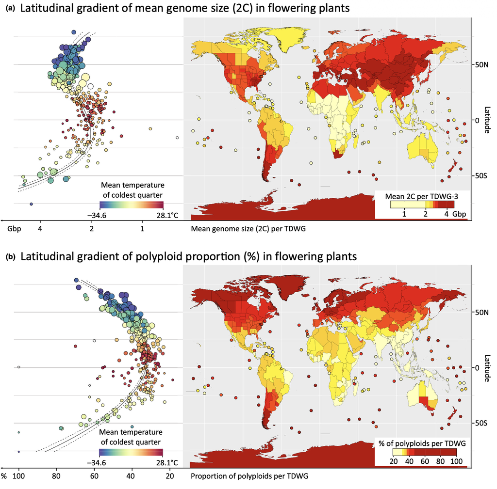

Smaller genomes towards the tropics. Fig. 3 of Bureš et al. (2024)

## Genome size: selection is context-dependent

Potential benefits to polyploidy during times of climate change

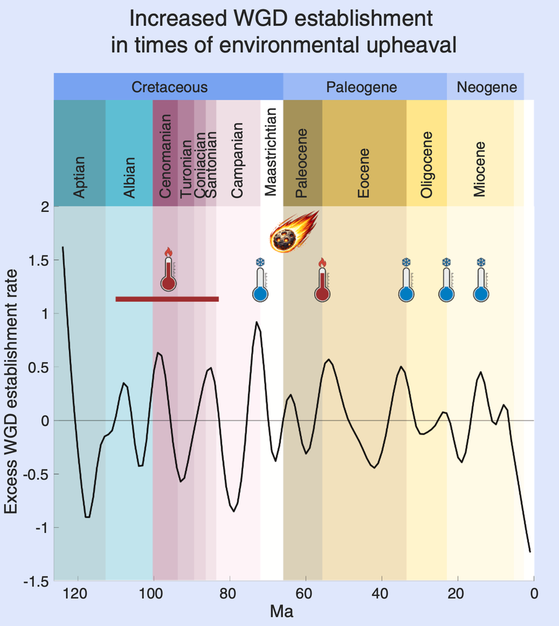

Clustering of WGDs near extinction events. Graphical abstract of Chen et al. (2026)

## Genome size: selection is context-dependent

Potential benefits to polyploidy during times of climate change

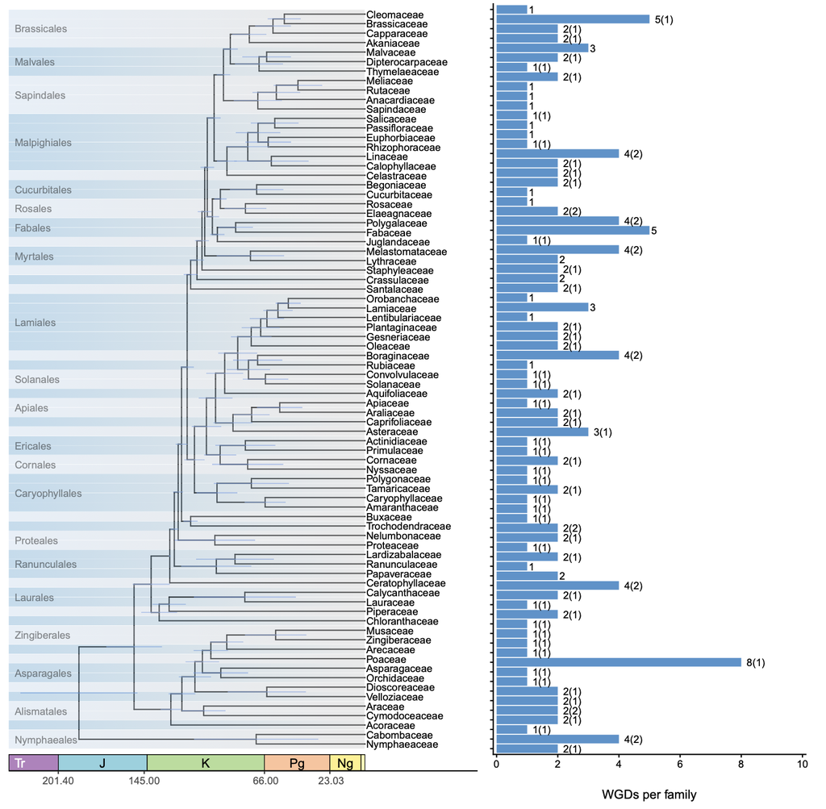

Clustering of WGDs near extinction events. Fig. 2 of Chen et al. (2026)

# Key takeaways

## Summary

- Gene tree reconciliation can show where duplications occur on a species tree
- Synteny is the gold standard for finding genes duplicated by WGD
- After a WGD, there is usually biased gene retention among subgenomes
- Most polyploids fail and the majority of cases do not provide the adaptive significance of our key innovations

## Coming up

- **Tuesday (Nov 24)** Computer activity and discussion on gene duplication and WGD.
- **Dec 1:** project presentations. **Dec 8:** exam 3.

# References

Amborella Genome Project. 2013. “The Amborella Genome and the Evolution of Flowering Plants.” *Science* 342 (6165): 1241089. https://doi.org/10.1126/science.1241089.

Bureš, Petr, Tammy L Elliott, Pavel Veselỳ, Petr Šmarda, Félix Forest, Ilia J Leitch, Eimear Nic Lughadha, et al. 2024. “The Global Distribution of Angiosperm Genome Size Is Shaped by Climate.” *New Phytologist* 242 (2): 744–59.

Chen, Hengchi, Fabricio Almeida-Silva, Garben Logghe, Steven Maere, Dries Bonte, and Yves Van de Peer. 2026. “The Rise of Polyploids During Environmental Upheaval.” *Cell* 189 (12): 3608–22.

Demuth, Jeffery P., and Matthew W. Hahn. 2009. “The Life and Death of Gene Families.” *BioEssays* 31 (1): 29–39. https://doi.org/10.1002/bies.080085.

Goodman, Morris, John Czelusniak, G William Moore, Alejo E Romero-Herrera, and Genji Matsuda. 1979. “Fitting the Gene Lineage into Its Species Lineage, a Parsimony Strategy Illustrated by Cladograms Constructed from Globin Sequences.” *Systematic Zoology*, 132–63.

Jaillon, O., J.-M. Aury, B. Noel, et al. 2007. “The Grapevine Genome Sequence Suggests Ancestral Hexaploidization in Major Angiosperm Phyla.” *Nature* 449 (7161): 463–67. https://doi.org/10.1038/nature06148.

Jiao, Yuannian, Norman J. Wickett, Saravanaraj Ayyampalayam, et al. 2011. “Ancestral Polyploidy in Seed Plants and Angiosperms.” *Nature* 473 (7345): 97–100. https://doi.org/10.1038/nature09916.

Li, Zheng, Anthony E. Baniaga, Emily B. Sessa, Moira Scascitelli, Sean W. Graham, Loren H. Rieseberg, and Michael S. Barker. 2015. “Early Genome Duplications in Conifers and Other Seed Plants.” *Science Advances* 1 (10): e1501084. https://doi.org/10.1126/sciadv.1501084.

Lynch, Michael, and John S. Conery. 2000. “The Evolutionary Fate and Consequences of Duplicate Genes.” *Science* 290 (5494): 1151–55. https://doi.org/10.1126/science.290.5494.1151.

Page, Roderic D. M. 1994. “Maps Between Trees and Cladistic Analysis of Historical Associations Among Genes, Organisms, and Areas.” *Systematic Biology* 43 (1): 58–77. https://doi.org/10.1093/sysbio/43.1.58.

Paterson, A. H., J. E. Bowers, and B. A. Chapman. 2004. “Ancient Polyploidization Predating Divergence of the Cereals, and Its Consequences for Comparative Genomics.” *Proceedings of the National Academy of Sciences* 101 (26): 9903–8. https://doi.org/10.1073/pnas.0307901101.

Pellicer, Jaume, Oriane Hidalgo, Steven Dodsworth, and Ilia J. Leitch. 2018. “Genome Size Diversity and Its Impact on the Evolution of Land Plants.” *Genes* 9 (2): 88. https://doi.org/10.3390/genes9020088.

Rabier, Charles-Elie, Tram Ta, and Cécile Ané. 2014. “Detecting and Locating Whole Genome Duplications on a Phylogeny: A Probabilistic Approach.” *Molecular Biology and Evolution* 31 (3): 750–62. https://doi.org/10.1093/molbev/mst263.

Schnable, James C., Nathan M. Springer, and Michael Freeling. 2011. “Differentiation of the Maize Subgenomes by Genome Dominance and Both Ancient and Ongoing Gene Loss.” *Proceedings of the National Academy of Sciences* 108 (10): 4069–74. https://doi.org/10.1073/pnas.1101368108.

Shi, Tao, and Yves Van de Peer. 2026. “Revisiting Ancient Whole-Genome Duplications in the Seed and Flowering Plants Through the Lens of Dosage-Sensitive Genes.” *Science Advances* 12 (1): eaea9797. https://doi.org/10.1126/sciadv.aea9797.

Soto Gomez, Marybel, Matilda JM Brown, Samuel Pironon, Petr Bureš, Luis D Verde Arregoitia, Pavel Veselỳ, Tammy L Elliott, et al. 2024. “Genome Size Is Positively Correlated with Extinction Risk in Herbaceous Angiosperms.” *New Phytologist* 243 (6): 2470–85.

Tang, Haibao, John E. Bowers, Xiyin Wang, Ray Ming, Maqsudul Alam, and Andrew H. Paterson. 2008. “Synteny and Collinearity in Plant Genomes.” *Science* 320 (5875): 486–88. https://doi.org/10.1126/science.1153917.

Tasdighian, Setareh, Michiel Van Bel, Zhen Li, Yves Van de Peer, Lorenzo Carretero-Paulet, and Steven Maere. 2017. “Reciprocally Retained Genes in the Angiosperm Lineage Show the Hallmarks of Dosage Balance Sensitivity.” *The Plant Cell* 29 (11): 2766–85. https://doi.org/10.1105/tpc.17.00313.

Tiley, George P., Cécile Ané, and J. Gordon Burleigh. 2016. “Evaluating and Characterizing Ancient Whole-Genome Duplications in Plants with Gene Count Data.” *Genome Biology and Evolution* 8 (4): 1023–37. https://doi.org/10.1093/gbe/evw058.

Van Bel, Michiel, Francesca Silvestri, Eric M Weitz, Lukasz Kreft, Alexander Botzki, Frederik Coppens, and Klaas Vandepoele. 2022. “PLAZA 5.0: Extending the Scope and Power of Comparative and Functional Genomics in Plants.” *Nucleic Acids Research* 50 (D1): D1468–74. https://doi.org/10.1093/nar/gkab1024.